# Ovule linkage map assembly in *Mimulus nudatus*

Elen Oneal

June 11, 2026

## Project overview

This report documents the processing and analysis workflow used to map the ovule mutant locus in an F2 population of *Mimulus nudatus*. It includes the following stages:

- ddRAD read preprocessing and barcode de-aggregation
- trimming, alignment, and read-group assignment for parents and F2s
- SNP calling and VCF filtering for LepMap3 input
- LepMap3 linkage group construction and marker ordering
- generation of phased genotype and mapping output files

For a concise pipeline roadmap and step-by-step script order, see `WORKFLOW.md`.

## Environment setup

This analysis was executed in R version 4.0.5 and relies on the following conda environments:

- `linkage-mapping_rmd` for rendering this Rmarkdown report
- `linkage-mapping` for the main analysis tools
- `py2` for legacy Python 2 ddRAD de-aggregation scripts

VCFtools is loaded via the HPC module system (module add VCFtools) in the pipeline chunks. If running outside an HPC environment, install VCFtools separately or add it to the linkage-mapping conda environment.

Create the environments using:

```bash
conda env create -f environment/linkage-mapping_rmd.yml -n linkage-mapping_rmd
conda env create -f environment/linkage-mapping_environment.yml -n linkage-mapping
conda env create -f environment/py2_environment.yml -n py2
```

Activate the report environment and render this document with:

```bash
conda activate linkage-mapping_rmd
Rscript -e "rmarkdown::render('Ovules.Rmd')"
```

## Key files

This report uses and generates the following key files:

- `data/ovule_plate_layout.txt` — plate layout for library preparation
- `data/ovule_library_filenames.txt` — raw ddRAD library filenames
- `data/ovule_samples.txt` — F2 sample list used for filtering
- `ovule_f2s.snps_only.vcf` — concatenated raw SNP VCF before filtering
- `ovule_f2s.min60.filtered.vcf` — filtered VCF input to LepMap3
- `ovule_f2s.min60.max3.vcf` — biallelic VCF after additional genotype filtering
- `ovule_f2s.min60.max3.thinned.vcf` — thinned VCF used for LepMap3 mapping
- `ovule.ped.txt` / `ovule.ped.transpose.txt` — pedigree files for LepMap3
- `order.10.20.0.0001.ovule_f2s.txt` — LepMap3 ordered marker output
- `ovule_f2s.10.20.phase.txt` — phased genotype output for downstream analysis

## Rationale

We did QTL mapping in an F2 mapping population to discover the loci underlying an ovule mutant in an inbred line of M. nudatus (GMR2). The mutant phenotype is characterized by an early arrest of the ovule integument and the later development of the ovule primordia into filamentous structures. Additionally, medusa mutant ovules fail to develop mature female gametophytes and are female sterile. An F2 population was created by first generating an F1 by crossing GMR2 (as pollen donor) to inbred line DHRO22, then selfing the F1. Both inbred lines were inbred for at least 6 generations. Phenotyping of F2s revealed that the ovule mutant appears to segregate at a 25-30% rate.

An Rmarkdown file (`scripts/Ovules.Rmd`) documents the analysis. The main report is rendered in `linkage-mapping_rmd`; legacy ddRAD de-aggregation scripts use the `py2` environment.

### Cross details

DHRO22 x GMR2 –> F1. Selfed F1 for 88 F2s.

The total number of sequenced individuals per backcross mapping populations is 88. Barcoded individuals were sequenced in two libraries. Plate layout is found in the file `data/ovule_plate_layout.txt`.

### Processing of ddRAD reads

Scripts for removing PCR duplicates and deaggregating barcoded F2s were written by Thom Nelson for Python 2.7.18. To execute them, use conda create -n py2 py2_environment.yml, then conda activate py2.

## Pipeline

Plate layout:

```r
plates <- read.table(here::here('data','ovule_plate_layout.txt'),h=F,sep='\t')
head(plates)
```

Fastq files with aggregated reads copied into the correct directory then renamed.

```bash
cp ~/data/SequencingRun_May2022/ddRADPlates_2022/JW77_*gz /work/01_mapping/03_ovules/
cp ~/data/SequencingRun_May2022/ddRADPlates_2022/JW78_*gz /work/01_mapping/03_ovules/
```

```bash
#rename and move sequencing files to new directory
./mvscript.sh
```

Execute the resulting scripts in py2 virtual environment

```bash
./rmdup.sh ovule_library_filenames.txt 01_rmdup common
for file in rmdup_*.sh; do sbatch $file; done
```

Execute the resulting scripts in py2 virtual environment

Flipreads.

Next use flip2BeRAD.py to flip the reads for each half-plate. From Thom Nelson: “For the bestRAD protocol, the genomic DNA fragment (including the inline barcode) gets randomly incorporated into the i5 and i7 adaptors, but the downstream steps require the first/forward read to contain the barcode and rad tag.”

“The output file will be called filtered_forward.fastq and filtered_reverse.fastq, so now is a good time to make separate folders for each half-plate and put the resultng files in those folders.”

```r
barcode_seqs <- read.table(here::here('data', 'ddrad_barcode_seqs.txt'), sep='\t', h=F)
head(barcode_seqs)
```

Number of mismatches for barcodes is set to 0. This insures that reads will be strictly from the individual labeled with that barcode. Setting this higher risks including errant reads and causing errors in genotyping.

Try with offset bases of 0 first. (“The number of basepairs to offset from the 5’ end of the read when searching for barcodes”)

```bash
./flip.sh ovule_library_filenames.txt 02_flipreads common
for file in *.flip.sh; do sbatch $file; done
```

Trim reads with trimmomatic v 0.39. Pull out barcodes using STACKS process_radtags http://catchenlab.life.illinois.edu/stacks/comp/process_radtags.php

Make directory for alignments then move deaggregated read files to alignment folder.

Trim and align parent reads, then add read groups. Parent read file names, sample names, and barcodes are in the ovule_genome_sequence_files.txt file. Filtering steps include marking PCR duplicates, retaining only properly paired reads with mapping quality >= 29, and excluding secondary and supplementary alignments.

```bash
./align_parents.sh ovule_genome_sequence_files.txt 03_align 00_parent_reads genome_dir Mguttatus.IM767.v2.fa common
./rg_parents.sh ovule_genome_sequence_files.txt 03_align/ picard_location common
```

Create a PseudoF1 by creating bam files from alignments of parents with sample read group “PseudoF1”. This is needed for pedigree for the linkage mapping downstream.

Create scripts to call SNPs with bcftools. im767.v2.list is a tab-delimited file with two columns. The first column is the coordinates for each contig given in list format. The second column is a name for that contig to be assigned to vcffiles. Bamlist.txt is a list of the bamfiles for F2s and parents. ovule_f2s is the prefix assigned to vcffiles for each contig. Bcftools filtering steps: 1) Filter based on mapping quality; 2) remove sites within 3 bp of an indeal; 3) keep only snps

Concatenate all scaffold vcf files with bcftools concat using text files that list all contig vcffiles.

### Use Lepmap3 to construct linkage map

Use the filtered VCF and `scripts/lepmap.sh` to construct linkage groups and order markers. Detailed filter script arguments are in the Diagnostics section below.

Get missing data for F2s. # Requires VCFtools — load via your HPC module system or activate a conda env that includes it # e.g.: module add VCFtools OR add to conda environment

```bash
cd 05_filter

if command -v vcftools &> /dev/null; then
    echo "VCFtools already available"
elif module add VCFtools 2>/dev/null; then
    echo "VCFtools loaded via module"
else
    echo "ERROR: VCFtools not found" && exit 1
fi

module add VCFtools

PRE=ovule_f2s
OUT=ovule_f2s

vcftools --vcf $OUT.snps_only.vcf --missing-indv
mv out.imiss $OUT.frac_missing_data.txt
```

Use custom python script to keep sites with minimum mapping quality 20, where inbred parents are homozygous, where F1 is heterozygous, where minimum and maximum parental depth are observed as indicated in the ovule_parents.txt file, and where a minimum of 60% of F2s have a minimum read depth of 4. Give outfile a prefix of ovule_f2s.min60. Mindepth and maxdepth are boolean variables (true or false).

Python script also outputs duplicate genotypes (denoted as ’_D1’) for each of the parents. These are useful for checking phasing done by LepMAP3 (see below)

```bash
cd 05_filter

PRE=ovule_f2s
OUT=ovule_f2s.min60

python filter_vcf_for_lepmap3_ovule_cross.py --invcf $PRE.snps_only.vcf --ParentList ovule_parents.txt --out $OUT --minMapQ 20 --filterInbredParents True --filterforhets True --minparentdepth True --maxparentdepth True --missingList $PRE.frac_missing_data.txt --MaxMissingData 1 --filterMissingParents True --FractionF2 60 --minF2depth 4 > out
```

Get missing data for all individuals. Keep only biallelic sites.

Thin vcffile to keep only snps more than 150 bp away from one another – this removes sites that are on the same read fragment and thus not independent.

```bash
cd 05_filter

PRE=ovule_f2s.min60.max3
OUT=ovule_f2s.min60.max3

module add VCFtools
vcftools --vcf $PRE.vcf --thin 150 --recode --recode-INFO-all --stdout > $OUT.thinned.vcf

vcftools --vcf $OUT.thinned.vcf --missing-indv
mv out.imiss $OUT.frac_missing_data.txt
```

Output of thinning script to vcftools:

VCFtools - 0.1.17 (C) Adam Auton and Anthony Marcketta 2009

Parameters as interpreted: –vcf ovule_f2s.min60.max3.vcf –recode-INFO-all –thin 150 –recode –stdout

Outputting VCF file… After filtering, kept 13376 out of a possible 27582 Sites Run Time = 2.00 seconds

(END)

Distribution of missing data. Create a histogram of missingness.

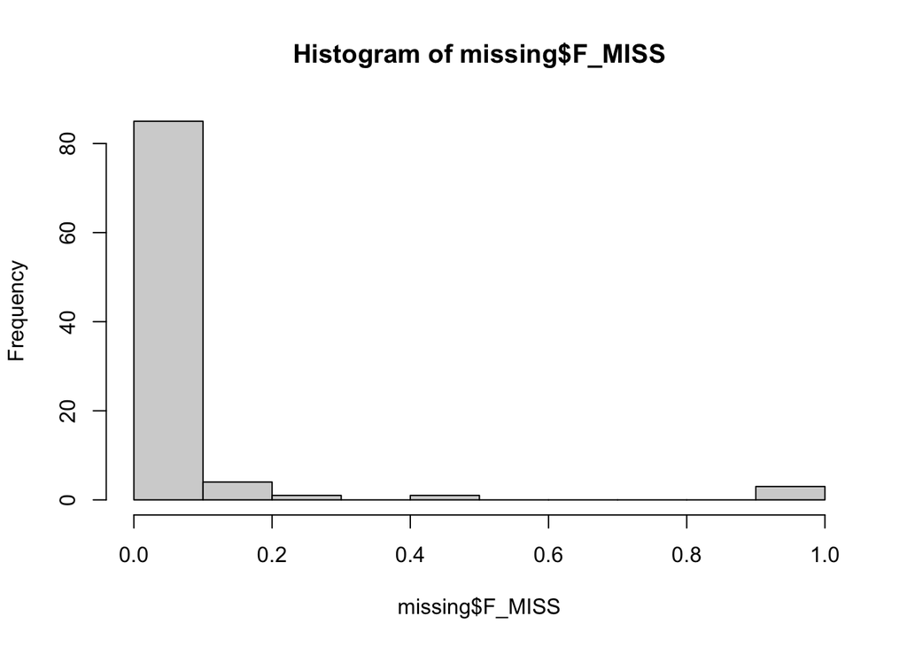

```
##         0%        25%        50%        75%       100%
## 0.00000000 0.01302707 0.01839115 0.02654005 0.98347800
```

```r
suppressMessages(library(dplyr))
missing <- read.table(here::here('data','ovule_f2s.min60.max3.frac_missing_data.txt'),h=T,sep='\t')
missing <- missing %>% filter(F_MISS<0.4)
f2s <- read.table(here::here('data','ovule_samples.txt'),h=F,sep='\t')
colnames(f2s) <- c('sample')
f2s <- f2s %>% filter(sample %in% missing$INDV)
write.table(f2s,here::here('data','ovule_samples_nomissing.txt'),quote=F,row.names=F,sep='\t',col.names=F)
```

Create pedigree file using bash scripting. DHRO22 is grandmother, GMR2 is grandfather, Pseudo F1s are created as mom and dad, then given as parents for F2s. Replicated sequences for DHRO22 and GMR2 were added into vcf to check phasing later on. The script is given here within the Rmarkdown file but was performed using lepmap.sh, which allows user to tune the lod and theta values.

Creating pedigree file requires datamash, which is in the yaml environment file.

Variables are hard coded in lepmap.sh but can be overridden by the user. PRE and OUT are user generated prefixes, lod = lod value, theta = theta value, and dT is the data tolerance threshold passed to LepMap3’s Filtering2. Markers are filtered by this threshold and the missing data limit; see LepMap3 documentation for details.

Output from lod = 10 and theta = 20 with data tolerance = 0.0001 and identicalLimit=0.01:

Warning: Different number of grandparents (4 and 2) in family Fam Found 2 grandparents in family Fam Number of individuals = 90 Number of families = 1 Number of called markers = 13327 (13327 informative) Number of called Z/X markers = 0 chi^2 limits are 15.1357421875, 18.419921875, 21.107421875 Warning: Different number of grandparents (4 and 2) in family Fam Found 2 grandparents in family Fam Number of individuals = 90 Number of families = 1 Number of markers = 13327 Loading file Warning: Different number of grandparents (4 and 2) in family Fam Found 2 grandparents in family Fam Number of individuals = 90 Number of families = 1 File loaded with 11497 SNPs Number of individuals = 88 excluding grandparents Number of families = 1 computing pairwise LOD scores 123456789 done! done! number of LGs = 14 singles = 10 Number of LGs = 14, markers in LGs = 11487, singles = 10

Get SNPs from .call file and phased genotype data. See LepMAP3 wiki for details. map2genotypes.awk is in a directory with lepmap3 modules

split_lepmap.py is a custom python script for creating a text file with mapping positions from lepmap output.

Usage: python script.py order_file: LepMap3 OrderMarkers2 output file output_prefix: prefix for output file (e.g. ‘ovule_f2s’) minorscafs: include scaffold contigs in output? (True or False)

Output: _mappingorder.txt

Best map is Lod 10 Theta 0.20 Filtered with data Tolerance = 0.0001 and identicalLimit=0.01

Getting phased genotypes for individuals. F2s were phased with grandparent phase (DHRO22 vs GMR2) and without filling in missing data. Assigns the DHRO22 homozygous genotype “2 2”, the GMR2 homozygous genotype “1 1”, and the heterozygous genotypes either “1 2” or “2 1”.

[interactive chart not shown]

I also checked the number of recombination events per F2 per linkage group. When an individual is outside the general distribution, it suggests well contamination.

Below is a plot of the distribution of recombination events per linkage group.

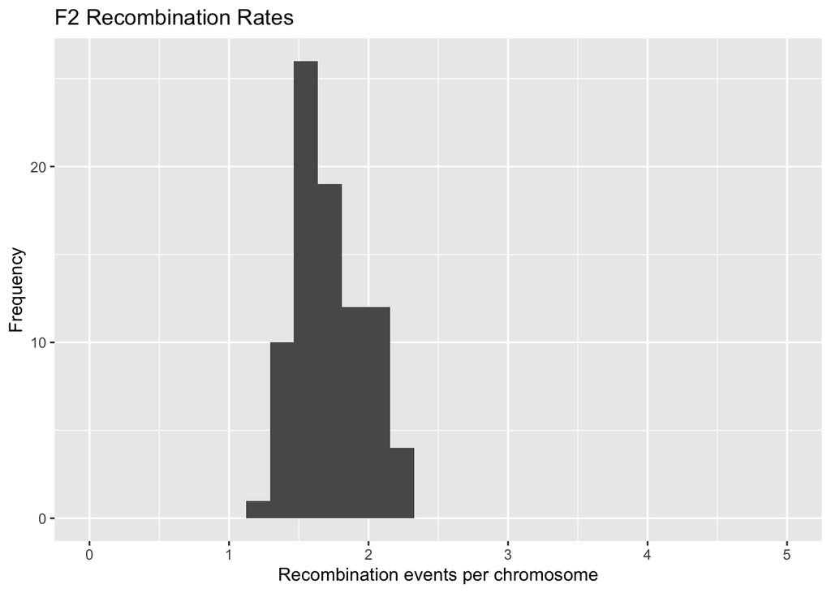

### Create phased genotype file

Some colleagues have found that LepMAP3 preferentially phases missing data as heterozygotes. Replace phases inferred by Lepmap3 with missing data as determined by genotype in vcf.

```bash
cd 05_filter
module add VCFtools
vcftools --vcf ovule_f2s.min60.max3.thinned.vcf --bed ovule_sites.bed --recode --recode-INFO-all --out ovule_f2s.finalsites
mv ovule_f2s.finalsites.recode.vcf ovule_f2s.finalsites.vcf
bgzip  ovule_f2s.finalsites.vcf
tabix  ovule_f2s.finalsites.vcf.gz
bcftools view -S ovule_samples_nomissing.txt ovule_f2s.finalsites.vcf.gz | bcftools query -f '%CHROM\t%POS\t%REF\t%ALT[\t%GT]\n' > ovule_f2s.finalsites.genotypes.txt
```

## Diagnostics

### filter_vcf_for_lepmap3_ovule_cross.py arguments

The filter script is used to select informative markers for LepMap3. The arguments are:

- `--invcf` : input VCF v4.1 file
- `--ParentList` : parent names, crossing direction, and depth filters
- `--SampleList` : tab-delimited sample list
- `--out` : output prefix
- `--minMapQ` : minimum phred-scaled mapping quality
- `--filterMissingParents` : drop sites with missing parents
- `--filterInbredParents` : remove heterozygous inbred parents
- `--filterforhets` : require heterozygous F1s
- `--minparentdepth` : enforce minimum parent depth filters
- `--maxparentdepth` : enforce maximum parent depth filters
- `--FractionF2` : fraction of F2s required to pass
- `--minF2depth` : minimum F2 depth
- `--missingList` : F2 missing-data file
- `--MaxMissingData` : maximum allowed missing data fraction

### Example filter command

```bash
cd 05_filter
python filter_vcf_for_lepmap3_ovule_cross.py \
  --invcf ovule_f2s.snps_only.vcf \
  --ParentList ovule_parents.txt \
  --out ovule_f2s.min60 \
  --minMapQ 20 \
  --filterInbredParents True \
  --filterforhets True \
  --minparentdepth True \
  --maxparentdepth True \
  --missingList ovule_f2s.frac_missing_data.txt \
  --MaxMissingData 1 \
  --filterMissingParents True \
  --FractionF2 60 \
  --minF2depth 4 > out
```

### Example output from the filter script

```
Arguments =  Namespace(FractionF2=60, MaxMissingData=1.0, ParentList='ovule_parents.txt', filterInbredParents=True, filterMissingParents=True, filterforhets=True, invcf='ovule_f2s.snps_only.vcf', maxparentdepth=True, minF2depth=4, minMapQ=20, minparentdepth=True, missingList='ovule_f2s.frac_missing_…
--- 6 minutes to complete task ---
There are 6721051 sites
There are 6720200 variant SNP sites
There are 6720200 sites with MQ >= 20
There are 2046079 sites with missing parents, 1106860 with het inbreds, and 4900739 with homozygous F1s
There are 3301518 sites with low parental depth
There are 520 sites with high parental depth
There are 3090698 sites where grandparents have the same genotype
There are 6570638 sites with fewer than 60 percent F2s
There are 149 sites with more than 3 F2 genotypes
There are 27602 final sites

Final number of lines in vcffile after keeping only biallelic sites:

line ovule_f2s.min60.max3.vcf
27638 ovule_f2s.min60.max3.vcf
```

Distribution of heterozygosity. Individuals with >80% heterozygosity will be treated as potential well contaminants during ddRAD library prep and removed from further analysis.

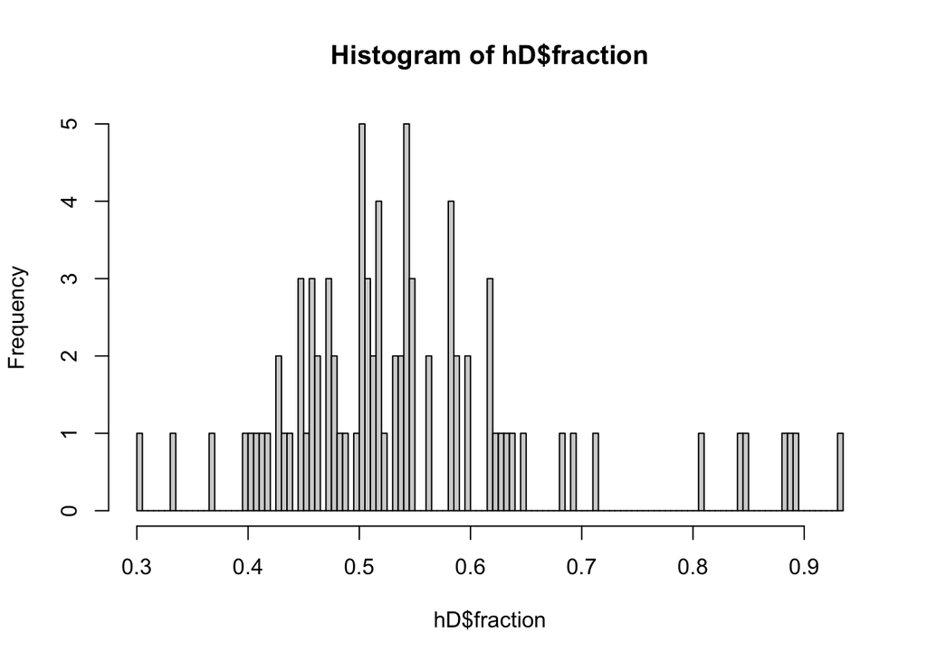

```r
suppressMessages(library(dplyr))
source(here::here('scripts','het_distribution.R'))

ovule.new.phase <- read.table(here::here('data','ovule_f2s_phased_w_missing.txt'),h=T,sep='\t')

homo1a <- '2 2'
homo1b <- 'AA'
homo2a <- '1 1'
homo2b <- 'BB'
het1a <- '1 2'
het1b <- 'AB'
het2a <- '2 1'

substitute_geno <- function(geno,homo1a,homo1b,homo2a,homo2b,het1a,het2a,het1b){
  df <- data.frame(lapply(geno,function(x){gsub(homo1a,homo1b,x)}))
  df <- data.frame(lapply(df,function(x){gsub(homo2a,homo2b,x)}))
  df <- data.frame(lapply(df,function(x){gsub(het1a,het1b,x)}))
  df <- data.frame(lapply(df,function(x){gsub(het2a,het1b,x)}))
#  df <- data.frame(lapply(df,function(x){gsub(NA,'NN',x)}))
  df$cM <- as.numeric(df$cM)
  return(df)
}

ovule.geno <- substitute_geno(ovule.new.phase,homo1a,homo1b,homo2a,homo2b,het1a,het2a,het1b)
df <- ovule.geno
for (col in names(df)) {
    # Replace NA with "NN" in each column
    df[is.na(df[[col]]), col] <- "NN"
}

d1 <- draw_het_distribution(df)
```

```r
median(d1$fraction)
```

```
## [1] 0.5190613
```

```r
mean(d1$fraction)
```

```
## [1] 0.5461994
```

```r
min(d1$fraction)
```

```
## [1] 0.3048068
```

```r
quantile(d1$fraction)
```

```
##        0%       25%       50%       75%      100%
## 0.3048068 0.4700122 0.5190613 0.5861904 0.9347466
```

```r
write.table(ovule.geno,here::here('data','ovule_sub_genotypes.txt'),quote=F,row.names=F,sep='\t',col.names=T)
highhet <- d1 %>% filter(fraction>=0.8) %>% select(sample)
ovule.geno <- df %>% select(-all_of(matches(highhet$sample)))
write.table(ovule.geno,here::here('data','ovule_sub_genotypes_missing_lowhet.txt'),quote=F,row.names=F,sep='\t')
```